# TP3 – Regresión Logística Binomial

Census Income USA – Análisis de factores socioeconómicos del ingreso

Autor/a

Sol Avalos

Fecha de publicación

2 de junio de 2026

## Librerías necesarias

```r
if (!require("pacman")) install.packages("pacman")
# Cargamos todas las librerías requeridas para la sesión
pacman::p_load(
  tidyverse,        # Manipulación de datos (dplyr, tidyr) y visualización(ggplot2)
  here,            # Manejo de rutas relativas al proyecto
  janitor,         # Limpieza de nombres de columnas
  scales,          # Formateo de ejes en gráficos
  broom,           # Convierte outputs de modelos a dataframes
  modelsummary,    # Tablas de comparación de modelos
  kableExtra,      # Decoración de tablas
  marginaleffects, # Efectos marginales promedio (AME)
  yardstick,       # Métricas de evaluación (ROC, AUC)
  patchwork        # Composición de gráficos
)
```

## Base de datos de ‘Adult Census Income’

```r
#Carga de datos
datos_raw <- read.csv(
  here("data", "adult_census_USA.csv"),
  stringsAsFactors = FALSE
)

glimpse(datos_raw)
```

```
Rows: 15,766
Columns: 14
$ age            <int> 28, 37, 49, 52, 31, 42, 37, 30, 38, 43, 40, 35, 43, 56,…
$ workclass      <chr> "Private", "Private", "Private", "Self-emp-not-inc", "P…
$ education      <chr> "Bachelors", "Masters", "9th", "HS-grad", "Masters", "B…
$ education_num  <int> 13, 14, 5, 9, 14, 13, 10, 13, 7, 14, 16, 5, 7, 13, 9, 1…
$ marital_status <chr> "Married-civ-spouse", "Married-civ-spouse", "Married-sp…
$ occupation     <chr> "Prof-specialty", "Exec-managerial", "Other-service", "…
$ relationship   <chr> "Wife", "Wife", "Not-in-family", "Husband", "Not-in-fam…
$ race           <chr> "Black", "White", "Black", "White", "White", "White", "…
$ sex            <chr> "Female", "Female", "Female", "Male", "Female", "Male",…
$ capital_gain   <int> 0, 0, 0, 0, 14084, 5178, 0, 0, 0, 0, 0, 0, 0, 0, 0, 0, …
$ capital_loss   <int> 0, 0, 0, 0, 0, 0, 0, 0, 0, 0, 0, 0, 2042, 0, 0, 0, 0, 0…
$ hours_per_week <int> 40, 40, 16, 45, 50, 40, 80, 40, 50, 45, 60, 40, 40, 40,…
$ native_country <chr> "Cuba", "United-States", "Jamaica", "United-States", "U…
$ income         <chr> "<=50K", "<=50K", "<=50K", ">50K", ">50K", ">50K", ">50…
```

```r
#Limpieza y transformacion de datos
datos <- datos_raw |>
  mutate(
    # Transformación de variable respuesta como factor con orden explícito de
    #niveles:
    # "<=50K" = referencia (nivel 1), ">50K" = clase a predecir (nivel 2)
    income = factor(income, levels = c("<=50K", ">50K")),

    # Sex como factor
    # "Female" como referencia: interpretaremos el efecto de ser Male
    # respecto a ser Female sobre la probabilidad de ingreso alto
    sex = factor(sex, levels = c("Female", "Male")),

    # Race como factor
    # "White" como referencia por ser la categoría mayoritaria.
    race = factor(race, levels = c("White", "Asian-Pac-Islander",
                                   "Amer-Indian-Eskimo", "Other", "Black")),

    # Education como factor ordenado de menor a mayor nivel
    # El orden importa para los gráficos y para la interpretación
    education = factor(education,
                       levels = c("Preschool","1st-4th","5th-6th",
                                  "7th-8th","9th","10th","11th","12th",
                                  "HS-grad","Some-college","Assoc-voc",
                                  "Assoc-acdm","Bachelors","Masters",
                                  "Prof-school","Doctorate"))
  )

# Verificación del balance
cat("Distribución de la variable objetivo:\n")
```

```
Distribución de la variable objetivo:
```

```r
table(datos$income)
```

```
<=50K  >50K
 8258  7508
```

```r
cat("\nProporciones:\n")
```

```
Proporciones:
```

```r
prop.table(table(datos$income)) |> round(3)
```

```
<=50K  >50K
0.524 0.476
```

```r
#La variable objetivo se encuentra prácticamente balanceada (52.4% <=50K, 47.6% >50K), lo que garantiza que el modelo no estará sesgado hacia ninguna de las dos clases.
```

## Análisis Exploratorio y Decisiones de Transformación

Hacemos un grafico por variable, es decir, hacemos tres gráficos.

### Education vs income:

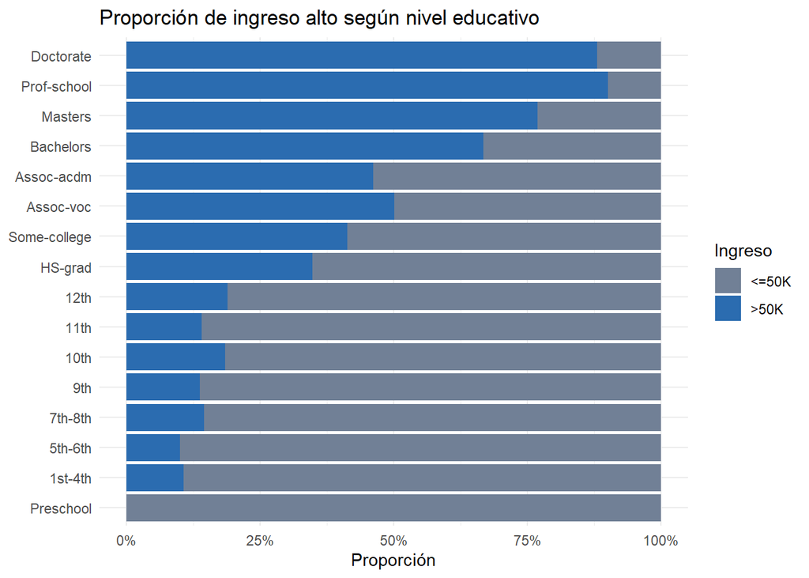

```r
datos |>
  ggplot(aes(x = education, fill = income)) +
  geom_bar(position = "fill") +
  scale_y_continuous(labels = scales::percent) +
  scale_fill_manual(values = c("<=50K" = "#718096", ">50K" = "#2B6CB0")) +
  coord_flip() +
  labs(
    title = "Proporción de ingreso alto según nivel educativo",
    x = NULL,
    y = "Proporción",
    fill = "Ingreso"
  ) +
  theme_minimal()
```

#### Interpretación:

Se observa una relación positiva clara: a mayor nivel educativo, mayor proporción de individuos con ingresos superiores a USD 50.000. Los niveles universitarios y de posgrado concentran la mayor proporción de ingresos altos, mientras que los niveles primarios y secundarios iniciales son casi exclusivamente de ingresos bajos.

### Sex vs. Income:

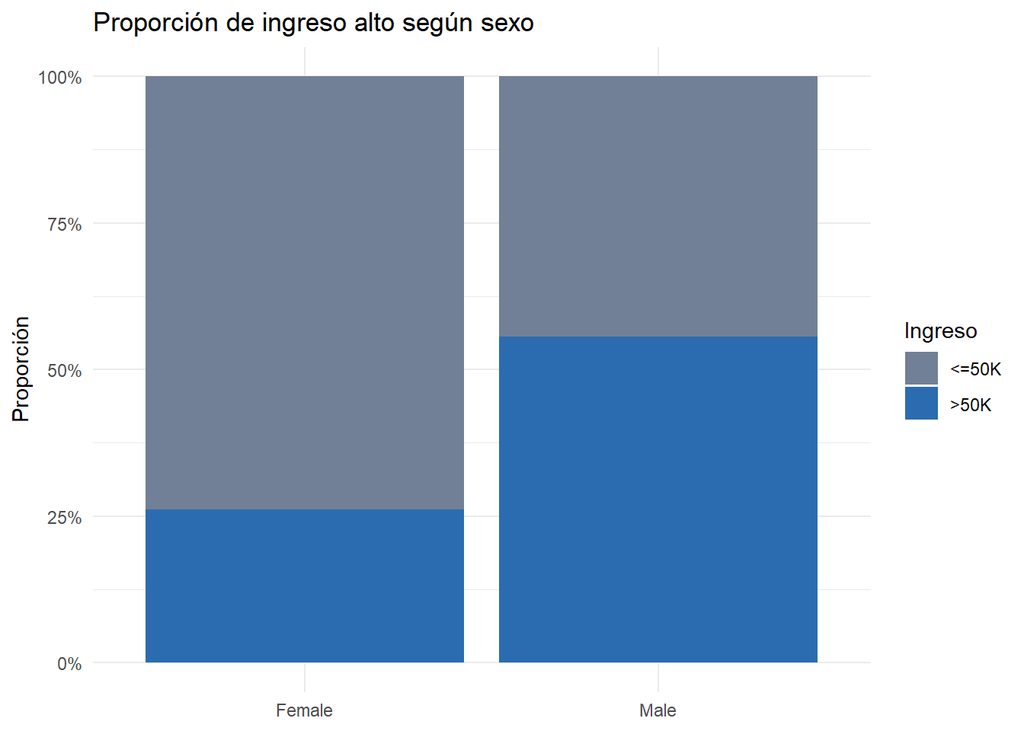

```r
datos |>
  ggplot(aes(x = sex, fill = income)) +
  geom_bar(position = "fill") +
  scale_y_continuous(labels = scales::percent) +
  scale_fill_manual(values = c("<=50K" = "#718096", ">50K" = "#2B6CB0")) +
  labs(
    title = "Proporción de ingreso alto según sexo",
    x = NULL,
    y = "Proporción",
    fill = "Ingreso"
  ) +
  theme_minimal()
```

#### Interpretación:

Existe una brecha marcada: los hombres presentan una proporción de ingresos altos cercana al 50%, mientras que en las mujeres no supera el 25%. Esto sugiere que el sexo es un predictor relevante del ingreso y motiva la inclusión de una interacción con educación en el modelo.

### Race vs. Income:

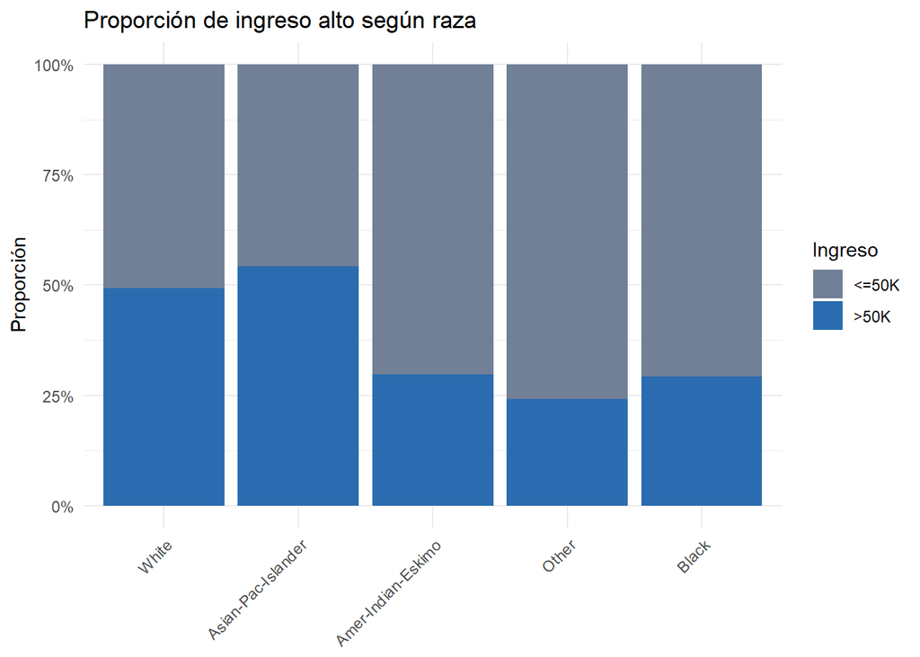

```r
datos |>
  ggplot(aes(x = race, fill = income)) +
  geom_bar(position = "fill") +
  scale_y_continuous(labels = scales::percent) +
  scale_fill_manual(values = c("<=50K" = "#718096", ">50K" = "#2B6CB0")) +
  labs(
    title = "Proporción de ingreso alto según raza",
    x = NULL,
    y = "Proporción",
    fill = "Ingreso"
  ) +
  theme_minimal() +
  theme(axis.text.x = element_text(angle = 45, hjust = 1))
```

#### Interpretación:

El grupo `Asian-Pac-Islander` registra la mayor proporción de ingresos altos, seguido por `White`. Los grupos `Black`, `Other` y `Amer-Indian-Eskimo` presentan proporciones considerablemente menores, lo que es consistente con la literatura sobre desigualdad racial en el mercado laboral estadounidense.

### **¿Es necesario transformar alguna variable continua?**

Si bien en el análisis exploratorio se utilizó `education` como factor para visualizar la distribución del ingreso en cada nivel educativo, la relación observada (positiva y progresiva sin saltos abruptos evidentes) justifica tratar la educación como variable continua en el modelo mediante `education_num`.

La variable `education_num`, toma valores enteros del 1 al 16 de forma ordenada y sin valores extremos problemáticos. Además, no presenta discontinuidades ni colas largas que distorsionen el ajuste. Por lo tanto, no es necesario aplicar ninguna transformación logarítmica sobre esta variable.

### **¿Necesitamos una interacción?**

Una hipótesis plausible es que **la brecha de género en el acceso a ingresos altos se amplía o se reduce según el nivel educativo**. Es decir, podríamos sospechar que el retorno económico de la educación no es equivalente para hombres y mujeres: a medida que aumenta el nivel educativo, la probabilidad de ingresos altos podría crecer de forma diferente para cada sexo. Esto es consistente con la literatura sobre brechas salariales de género, que documenta que las mujeres frecuentemente necesitan mayores credenciales educativas para acceder a posiciones equivalentes a las de sus pares masculinos.

El gráfico exploratorio de sexo refuerza esta sospecha: la brecha entre hombres y mujeres es marcada incluso sin controlar por educación, lo que sugiere que el efecto combinado de ambas variables merece ser modelado explícitamente mediante el término de interacción `education_num * sex`.

## Ajuste de Modelos (Regresión Logística)

```r
# Modelo 1: efectos principales sin interacción
# Categorías de referencia:
# - sex: "Female"
# - race: "White"
modelo_base <- glm(
  income ~ education_num + sex + race,
  family = binomial,
  data   = datos
)


# Modelo 2: incluye el término de interacción education_num * sex
# La notación A * B es equivalente a A + B + A:B
# es decir, incluye ambos efectos principales más el término de interacción
modelo_int <- glm(
  income ~ education_num * sex + race,
  family = binomial,
  data   = datos
)

summary(modelo_base)
```

```
Call:
glm(formula = income ~ education_num + sex + race, family = binomial,
    data = datos)

Coefficients:
                        Estimate Std. Error z value Pr(>|z|)
(Intercept)            -4.889133   0.100208 -48.790  < 2e-16 ***
education_num           0.360059   0.008224  43.782  < 2e-16 ***
sexMale                 1.356403   0.043196  31.401  < 2e-16 ***
raceAsian-Pac-Islander -0.079327   0.109514  -0.724  0.46885
raceAmer-Indian-Eskimo -0.467902   0.219814  -2.129  0.03329 *
raceOther              -0.912232   0.278221  -3.279  0.00104 **
raceBlack              -0.472183   0.070926  -6.657 2.79e-11 ***
---
Signif. codes:  0 '***' 0.001 '**' 0.01 '*' 0.05 '.' 0.1 ' ' 1

(Dispersion parameter for binomial family taken to be 1)

    Null deviance: 21821  on 15765  degrees of freedom
Residual deviance: 18127  on 15759  degrees of freedom
AIC: 18141

Number of Fisher Scoring iterations: 4
```

```r
summary(modelo_int)
```

```
Call:
glm(formula = income ~ education_num * sex + race, family = binomial,
    data = datos)

Coefficients:
                       Estimate Std. Error z value Pr(>|z|)
(Intercept)            -5.00553    0.20217 -24.759  < 2e-16 ***
education_num           0.37040    0.01762  21.025  < 2e-16 ***
sexMale                 1.50298    0.22475   6.687 2.27e-11 ***
raceAsian-Pac-Islander -0.07866    0.10944  -0.719  0.47232
raceAmer-Indian-Eskimo -0.47109    0.21997  -2.142  0.03223 *
raceOther              -0.91248    0.27804  -3.282  0.00103 **
raceBlack              -0.47148    0.07096  -6.644 3.05e-11 ***
education_num:sexMale  -0.01323    0.01989  -0.665  0.50600
---
Signif. codes:  0 '***' 0.001 '**' 0.01 '*' 0.05 '.' 0.1 ' ' 1

(Dispersion parameter for binomial family taken to be 1)

    Null deviance: 21821  on 15765  degrees of freedom
Residual deviance: 18127  on 15758  degrees of freedom
AIC: 18143

Number of Fisher Scoring iterations: 4
```

## Interpretación de Resultados y Efectos Marginales

### Efectos marginales promedio (AME)

```r
# Calculamos el AME estándar (dY/dX) para todas las variables del modelo
ame <- avg_slopes(
  modelo_int,
  variables = c("education_num", "sex", "race"),
  slope = "dydx"
)

# Mostramos en tabla limpia
ame |>
  select(term, contrast, estimate, conf.low, conf.high, p.value) |>
  mutate(
    estimate_pct = paste0(round(estimate * 100, 2), "%"),
    interpretacion = case_when(
      estimate > 0 & p.value < 0.05 ~ "Aumenta prob. (Sig.)",
      estimate < 0 & p.value < 0.05 ~ "Reduce prob. (Sig.)",
      TRUE ~ "No significativo"
    )
  ) |>
  select(term, contrast, estimate_pct, conf.low, conf.high, p.value, interpretacion) |>
  rename(
    `Predictor`      = term,
    `Contraste`      = contrast,
    `Efecto (Prob)`  = estimate_pct,
    `IC Inferior`    = conf.low,
    `IC Superior`    = conf.high,
    `Valor p`        = p.value,
    `Interpretación` = interpretacion
  ) |>
  knitr::kable(
    digits = 4,
    caption = "Efectos Marginales Promedio (Cambio en Probabilidad)"
  ) |>
  kable_styling(
    bootstrap_options = c("striped", "hover", "condensed", "responsive"),
    full_width = FALSE,
    position = "center"
  ) |>
  row_spec(
    row = which(ame$p.value < 0.05),
    bold = TRUE,
    color = "black",
    background = "#e6f2ff"
  )
```

Efectos Marginales Promedio (Cambio en Probabilidad)

| Predictor | Contraste | Efecto (Prob) | IC Inferior | IC Superior | Valor p | Interpretación |
| --- | --- | --- | --- | --- | --- | --- |
| education_num | dY/dX | 7.07% | 0.0683 | 0.0731 | 0.0000 | Aumenta prob. (Sig.) |
| race | Amer-Indian-Eskimo - White | -9.22% | -0.1747 | -0.0097 | 0.0285 | Reduce prob. (Sig.) |
| race | Asian-Pac-Islander - White | -1.56% | -0.0580 | 0.0268 | 0.4718 | No significativo |
| race | Black - White | -9.22% | -0.1190 | -0.0655 | 0.0000 | Reduce prob. (Sig.) |
| race | Other - White | -17.33% | -0.2688 | -0.0778 | 0.0004 | Reduce prob. (Sig.) |
| sex | Male - Female | 26.96% | 0.2543 | 0.2849 | 0.0000 | Aumenta prob. (Sig.) |

#### Interpretación directa (AME):

- `education_num` (dY/dX): en promedio poblacional, un aumento de un nivel educativo aumenta la probabilidad absoluta de tener ingresos superiores a USD 50.000 en 7.07 puntos porcentuales. Es el segundo predictor más fuerte del modelo.
- `sex` (Male - Female): en promedio, los hombres tienen una probabilidad 26.96 puntos porcentuales mayor de pertenecer al estrato de ingresos altos que las mujeres. Es, por lejos, el predictor más fuerte del modelo.
- `race`: los grupos `Black` y `Amer-Indian-Eskimo` presentan una probabilidad aproximadamente 9.22 puntos porcentuales menor que la población blanca, mientras que `Other` muestra la brecha más amplia con -17.33 puntos porcentuales. `Asian-Pac-Islander` no resultó significativo: a pesar de mostrar la mayor proporción de ingresos altos en el análisis exploratorio, al controlar por educación y sexo el efecto desaparece, lo que sugiere que esa ventaja se explicaría por su composición educativa más que por la pertenencia racial en sí misma.
- `education_num:sexMale`: el término de interacción no resultó significativo. Al promediar sobre todas las observaciones, no hay evidencia de que el retorno económico de la educación difiera entre hombres y mujeres en este dataset.

## Gráfico de Coeficientes (Odds Ratios) con barras graduadas

```
`height` was translated to `width`.
`height` was translated to `width`.
`height` was translated to `width`.
```

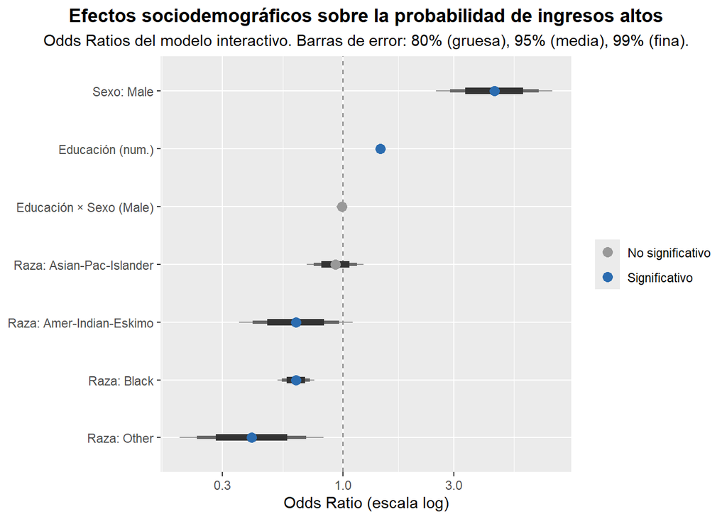

```r
# Extraemos los coeficientes del modelo interactivo con broom
or_data <- tidy(modelo_int, conf.int = TRUE, conf.level = 0.95) |>
  filter(term != "(Intercept)") |>
  mutate(
    # Exponenciamos para obtener Odds Ratios
    or      = exp(estimate),
    ci80_lo = exp(estimate - qnorm(0.90) * std.error),
    ci80_hi = exp(estimate + qnorm(0.90) * std.error),
    ci95_lo = exp(estimate - qnorm(0.975) * std.error),
    ci95_hi = exp(estimate + qnorm(0.975) * std.error),
    ci99_lo = exp(estimate - qnorm(0.995) * std.error),
    ci99_hi = exp(estimate + qnorm(0.995) * std.error),
    # Etiquetas más legibles para el gráfico
    term = recode(term,
                  "education_num"          = "Educación (num.)",
                  "sexMale"                = "Sexo: Male",
                  "raceAsian-Pac-Islander" = "Raza: Asian-Pac-Islander",
                  "raceAmer-Indian-Eskimo" = "Raza: Amer-Indian-Eskimo",
                  "raceOther"              = "Raza: Other",
                  "raceBlack"              = "Raza: Black",
                  "education_num:sexMale"  = "Educación × Sexo (Male)"
    ),
    # Significancia para colorear
    significativo = p.value < 0.05
  )

# Forest plot
ggplot(or_data, aes(x = or, y = reorder(term, or))) +
  # Línea de referencia en OR = 1 (sin efecto)
  geom_vline(xintercept = 1, linetype = "dashed", color = "gray50") +
  # IC 99% — más fino
  geom_errorbarh(aes(xmin = ci99_lo, xmax = ci99_hi),
                 height = 0, linewidth = 0.5, color = "gray60") +
  # IC 95% — grosor medio
  geom_errorbarh(aes(xmin = ci95_lo, xmax = ci95_hi),
                 height = 0, linewidth = 1.2, color = "gray40") +
  # IC 80% — más grueso
  geom_errorbarh(aes(xmin = ci80_lo, xmax = ci80_hi),
                 height = 0, linewidth = 2.2, color = "gray20") +
  # Punto central (OR)
  geom_point(aes(color = significativo), size = 3) +
  scale_color_manual(values = c("TRUE" = "#2B6CB0", "FALSE" = "gray60"),
                     labels = c("TRUE" = "Significativo", "FALSE" = "No significativo"),
                     name = NULL) +
  # Escala logarítmica en X como pide la consigna
  scale_x_log10() +
  labs(
    title    = "Efectos sociodemográficos sobre la probabilidad de ingresos altos",
    subtitle = "Odds Ratios del modelo interactivo. Barras de error: 80% (gruesa), 95% (media), 99% (fina).",
    x        = "Odds Ratio (escala log)",
    y        = NULL
  ) +
  theme(
  plot.title    = element_text(face = "bold", hjust = 0.5),
  plot.subtitle = element_text(hjust = 0.5)
)
```

#### **Interpretación de los Odds Ratios (variables significativas):**

- `Sexo: Male`: los hombres tienen aproximadamente 4.5 veces más chances de pertenecer al estrato de ingresos altos que las mujeres, manteniendo el resto de las variables constantes. Es el efecto más pronunciado del modelo.
- `Educación (num.)`: por cada nivel adicional de educación, las chances de tener ingresos altos aumentan un 45% aproximadamente. El efecto es acumulativo y estadísticamente muy robusto.
- `Raza: Black`: las personas de raza negra tienen aproximadamente un 37% menos chances de pertenecer al estrato de ingresos altos respecto a la población blanca.
- `Raza: Amer-Indian-Eskimo`: este grupo presenta aproximadamente un 37% menos chances que la categoría de referencia, similar a `Black`.
- `Raza: Other`: es el grupo con la mayor desventaja relativa, con aproximadamente un 60% menos chances que la población blanca.
- `Educación × Sexo (Male)`: el término de interacción no resultó significativo, lo que indica que no hay evidencia de que el efecto de la educación sobre las chances de ingresos altos difiera entre hombres y mujeres en este dataset.

## Comparación Global de Modelos

```r
bind_rows(
  broom::glance(modelo_base) |> mutate(Modelo = "1. Sin interacción"),
  broom::glance(modelo_int)  |> mutate(Modelo = "2. Con interacción")
) |>
  mutate(pseudo_r2 = 1 - (deviance / null.deviance)) |>
  select(Modelo, null.deviance, deviance, pseudo_r2, AIC, nobs) |>
  rename(
    `Deviance Nula`        = null.deviance,
    `Deviance Residual`    = deviance,
    `Pseudo-R² (McFadden)` = pseudo_r2,
    `Observaciones`        = nobs
  ) |>
  knitr::kable(
    digits  = c(0, 1, 1, 3, 1, 0),
    caption = "Comparación global de modelos — Regresión logística binomial"
  ) |>
  kable_styling(
    bootstrap_options = c("striped", "hover", "condensed", "responsive"),
    full_width = FALSE,
    position = "center"
  ) |>
  row_spec(
    row        = 1,  # Resaltamos el modelo base porque es el que tiene menor AIC
    bold       = TRUE,
    color      = "black",
    background = "#e6f2ff"
  )
```

Comparación global de modelos — Regresión logística binomial

| Modelo | Deviance Nula | Deviance Residual | Pseudo-R² (McFadden) | AIC | Observaciones |
| --- | --- | --- | --- | --- | --- |
| 1. Sin interacción | 21820.6 | 18127.1 | 0.169 | 18141.1 | 15766 |
| 2. Con interacción | 21820.6 | 18126.7 | 0.169 | 18142.7 | 15766 |

#### Interpretación:

La comparación global de modelos indica que la inclusión del término de interacción `education_num * sex` no mejora el ajuste. El modelo base y el interactivo explican la misma proporción de variación en el ingreso (Pseudo-R² de 0.169 en ambos casos), y la diferencia en AIC es mínima (de hecho, el modelo base tiene un AIC levemente menor, lo que significa que es preferible). En términos simples: incorporar la hipótesis de que el efecto de la educación es distinto para hombres y mujeres no agrega información útil al modelo. El modelo más simple explica los datos igual de bien, y por eso es el que nos quedamos.

## Conclusión

El análisis buscó identificar qué factores sociodemográficos determinan la probabilidad de que un ciudadano estadounidense pertenezca al estrato de ingresos altos (más de USD 50.000 anuales). Los tres predictores seleccionados (sexo, nivel educativo y raza) resultaron en conjunto altamente relevantes, aunque con matices importantes.

El hallazgo más contundente es la brecha de género. Ser hombre incrementa en casi 27 puntos porcentuales la probabilidad de tener ingresos altos respecto a ser mujer, independientemente del nivel educativo o la raza. Este resultado no sorprende a la luz de la literatura sobre mercados laborales, pero su magnitud es llamativa, ya que el sexo resultó ser el predictor más fuerte del modelo, por encima incluso de la educación.

La educación, por su parte, tiene un efecto positivo y robusto: cada nivel adicional de escolaridad aumenta en promedio 7 puntos porcentuales la probabilidad de ingresos altos. Sin embargo, la hipótesis de que ese retorno educativo es distinto para hombres y mujeres, no encontró respaldo en los datos. El modelo interactivo no mejora al modelo base ni en ajuste ni en capacidad explicativa, lo que sugiere que la brecha de género opera de forma relativamente uniforme a lo largo de todos los niveles educativos.

En cuanto a la raza, los resultados muestran desigualdades estructurales persistentes. Los grupos `Black`, `Amer-Indian-Eskimo` y `Other` presentan probabilidades significativamente menores de acceder a ingresos altos respecto a la población blanca, aun controlando por educación y sexo. Esto indica que la desventaja racial no se explica únicamente por diferencias en el nivel educativo, sino que refleja barreras adicionales en el mercado laboral. El caso de `Asian-Pac-Islander` es particularmente interesante. A pesar de mostrar la mayor proporción de ingresos altos en el análisis exploratorio, su efecto desaparece al controlar por las demás variables, lo que sugiere que esa ventaja aparente se debe a su mayor nivel educativo promedio y no a la pertenencia racial en sí misma.

En síntesis, el modelo revela que el ingreso en Estados Unidos está fuertemente influenciado por el género y atravesado por desigualdades raciales que persisten más allá de la educación. La educación importa, pero no alcanza para explicar por sí sola quién accede al estrato de ingresos altos.